# manuscript

**Improving Clonal Propagation of *Eucalyptus grandis x urophylla* with Indole-3-Butyric Acid**

Sebastian Casas-Niño<sup>1,4*</sup>; Gino Mondragón Aguirre<sup>2</sup>; Flavio Lozano-Isla<sup>3,4</sup>; José-Eloy Cuellar Bautista<sup>1</sup>.

*<sup>1</sup> Centro de Investigación en Silvicultura y Mejoramiento Forestal, Facultad de Ciencias Forestales. Universidad Nacional Agraria La Molina, Perú.*

*<sup>2</sup> Laboratorio de Silvicultura, Escuela Profesional de Ingeniería Forestal y Ambiental. Universidad Nacional de Jaén, Perú.*

*<sup>3</sup> Facultad de Ingeniería y Ciencias Agrarias, Universidad Nacional Toribio Rodríguez de Mendoza de Amazonas (UNTRM), Chachapoyas, Perú.*

*<sup>4</sup> Dirección de Supervisión y Monitoreo en las Estaciones Experimentales Agrarias (DSME), Instituto Nacional de Innovación Agraria. Lima, Perú.*

* Corresponding author: 20140231@lamolina.edu.pe

ORCID IDs:

Sebastian Casas-Niño: 0000-0002-6576-8761

Gino Mondragón Aguirre: 0000-0002-4608-7928

Flavio Lozano-Isla: 0000-0002-0714-669X

José Eloy Cuellar Bautista: 0000-0001-5087-5719

**Highlights**

- Indole-3-butyric acid (IBA) enhances the rooting of *Eucalyptus urograndis* cuttings in nurseries in the Peruvian central jungle.
- Indole-3-butyric acid (IBA) enhances root development in *Eucalyptus urograndis* cuttings during the rooting process.
- Selecting an optimal dose of indole-3-butyric acid (IBA) for the propagation of *Eucalyptus urograndis* maximizes rooting efficiency while preventing toxicity effects or root formation failure.
- Clonal propagation of *Eucalyptus urograndis* through IBA-rooted cuttings can be employed in commercial reforestation programs.

**Declarations**

**Funding**

This research has not received specific funding from public, commercial, or nonprofit organizations.

**Conflict of Interest**

The authors declare no conflicts of interest.

**Author Contributions**

Conceptualization, S.C-N., G.M., and J-E.C.; methodology, S.C-N.; formal analysis, S.C-N. and F.L-I.; investigation, S.C-N.; data curation, S.C-N. and F.L-I.; writing—original draft preparation, G.M., J-E.C., F.L-I., and S.C-N.; writing—review and editing, F.L-I., G.M., and J-E.C.; visualization, S.C-N. All authors have read and agreed to the published version of the manuscript.

**Acknowledgments**

The authors express their gratitude to TECFOREST and the Centro de Investigación en Silvicultura y Mejoramiento Forestal de la Facultad de Ciencias Forestales de la Universidad Nacional Agraria La Molina CESILMEF-FCF UNALM for their support.

**Data availability**

The original contributions presented in this study are included in the article and supplementary material. Reproducible datasets and data analysis are available in Supplementary File 1 and can be accessed via the GitHub repository at: [https://github.com/Sebass96/enraizamiento](https://github.com/Sebass96/enraizamiento.git)

**Keywords:** asexual propagation; cloning; cuttings; forest nursery; rhizogenesis; rooting agents; root development.

# 1 **INTRODUCTION**

According to the *Global Forest Resources Assessment 2020* [(FAO, 2021)](https://www.zotero.org/google-docs/?ibPAxG), there are 131 million hectares of commercial forest plantations (CFP) worldwide, representing 3% of the global forest area. Although the total area of CFPs increased between 2010 and 2020, the average annual growth rate of 1.48 million hectares per year was lower than that recorded in previous decades. In the Americas, the trends vary across regions. North America, Central America, and the Caribbean account for 15,177 thousand hectares of CFPs, while South America holds 20,099 thousand hectares. Similar to global trends, the annual expansion rate of CFPs in the Americas declined during the 2010–2020 decade, primarily due to influence of the United States (North America) and Brazil (South America). Other countries, including Chile, Colombia, Peru, and Uruguay, also influenced this trend.

In Peru, *Forest and Wildlife Law N° 29763* define forest plantations as human-created ecosystems where one or more forest species - either native or introduced - are established to produce timber forest products (TFP), non-timber forest products (NTFP), or provide ecosystem services, or a combination of these [(Servicio Nacional Forestal y de Fauna Silvestre, 2015)](https://www.zotero.org/google-docs/?xVic1j). Beyond supplying raw materials and goods, CFPs contribute to reducing pressure on timber extraction from natural forests [(Pirard et al., 2016)](https://www.zotero.org/google-docs/?jtDYR6), mitigating climate change through carbon sequestration and storage [(Osuri et al., 2020)](https://www.zotero.org/google-docs/?6lwB66), providing provisioning and supporting ecosystem services [(Zeng et al., 2021)](https://www.zotero.org/google-docs/?zCR3dp) and enhancing biodiversity conservation [(Silva et al., 2019)](https://www.zotero.org/google-docs/?E33P1p).

According to the *Global Forest Resources Assessment 2020*: Peru [(FAO, 2021)](https://www.zotero.org/google-docs/?DWy8xQ), the country has 1,088,470 hectares of CFPs. However, these figures may not be entirely precise, as plantation areas are estimated based on the number of seedlings planted or distributed from nurseries. Furthermore, available data do not clearly differentiate between forest plantations on state, communal, or private lands [(Guariguata et al., 2017)](https://www.zotero.org/google-docs/?oRVbpy). Despite progress in plantation establishment, CFP productivity in Peru remains low, mainly due to poor silvicultural management, minimal incorporation of genetic improvement, limited soil enhancement techniques, and the absence of site selection criteria for plantations [(Guariguata et al., 2017)](https://www.zotero.org/google-docs/?lv1MaP).

To foster the development of CFPs in Peru, the implementation of a comprehensive and coordinated forest policy is essential. A critical first step involves identifying and establishing strategic economic corridors for the forest industry, where CFPs can be concentrated. Additionally, securing legal land tenure for public lands is necessary to complement private plantation initiatives. Plantation programs should incorporate both native and introduced species; however, species selection must also align with market demand [(Servicio Nacional Forestal y Fauna Silvestre, 2021)](https://www.zotero.org/google-docs/?VC7ZsU). Moreover, technological development, research, and innovation are key tools required to enhance the growth and sustainability of CFPs.

To address these challenges, several initiatives have been implemented. One notable example is the introduction of the hybrid *Eucalyptus grandis × E. urophylla* into CFP projects in the Amazonian regions of Ucayali, Huánuco, Junín, Pasco, and San Martín [(Servicio Nacional Forestal y Fauna Silvestre, 2021)](https://www.zotero.org/google-docs/?oQg7aN). This hybrid is widely used in technified nurseries that propagate clonal material due to its fast growth and high productivity. Another significant measure has been the application of vegetative propagation, an efficient technique for maintaining genetic quality over relatively short periods. This approach reduces dependence on botanical seeds of unknown origin and enables the continuous production of clonal cuttings throughout the year [(Cachique et al., 2011)](https://www.zotero.org/google-docs/?98h7OB).

The implementation of vegetative propagation techniques plays a crucial role in forest genetic improvement and the increased productivity of CFPs in the Peruvian Amazon. These techniques help preserve the enhanced genetic traits in plantations established with asexually propagated seedlings. Productivity gains result from factors such as uniformity in wood’s physical and mechanical properties, the formation of high-quality tree trunks, increased resistance to diseases, pests, and extreme environmental conditions, higher annual growth rates, and improved forest management efficiency [(Abedini, 2005](https://www.zotero.org/google-docs/?1uVIwL); [Navarrete-Luna & Vargas-Hernández, 2005)](https://www.zotero.org/google-docs/?xcEnCs).

Despite the high potential of these techniques, asexual propagation of commercial species remains underexplored in Peru, particularly for the *Eucalyptus grandis × E. urophylla* hybrid. To promote environmentally and economically sustainable CFPs that contribute to the livelihoods of Amazonian communities, this study investigates the effect of indole-3-butyric acid (IBA) on the rooting and root development of *Eucalyptus grandis × E. urophylla* cuttings. The primary objective is to determine the optimal IBA concentration for commercial propagation, thereby supporting the sustainable development of Peru’s forest sector.

# 2 **MATERIALS AND METHODS**

## 2.1 **Study Area**

This study was conducted in the greenhouse of TEC FOREST S.A.C., located in the district of San Martín de Pangoa, province of Satipo, Junín region, Peru. The site is geographically positioned at 11° 25’ 24.72” S, 74° 29’ 17.20” W (-11.42353 S, -74.4881 W) at an altitude of 792 meters above sea level (m a.s.l.) (Figure 1). The mean temperature in the study area ranges between 19°C and 35°C. The precipitation regime is seasonal, with a rainy season from October to April and a dry season from May to September [(Servicio Nacional de Meteorología e Hidrología del Perú, 2024)](https://www.zotero.org/google-docs/?JHqz3B). Within the greenhouse, temperatures ranged from 25°C to 30°C, and the relative humidity varied between 60% and 70%.

## 2.2 **Plant Material**

The cuttings used in this study were obtained from mother plants of the *Eucalyptus grandis × E. urophylla* clone, identified with the code TF-001. These mother plants were seven months old, with an average height of 1.80 m and an average diameter at breast height (DBH) of 10 cm. The plant material of this clone was imported from Brazil as part of a batch consisting of eight clones selected through a technological innovation program in forest plantations.

Initially, these clones were established in a clonal research plot in Oxapampa as part of a project aimed at evaluating the adaptation and growth of clones under Peruvian conditions. Successive propagation processes were carried out in this plot to ensure the availability of high-quality vegetative material. From this material, experimental plots were implemented in various sites across the Peruvian central jungle, covering an altitudinal gradient ranging from 300 m a.s.l. in Iscozacín (Pichis Palcazú) to 3,000 m a.s.l. in Palca, Tarma.

The production of these clones was managed in the clonal garden of TEC FOREST S.A.C., using plant material sourced from the district of Palca, province of Tarma, department of Junín [(Machacuay & Llancari, 2020)](https://www.zotero.org/google-docs/?rMvsuq).

## 2.3 **Experimental stage**

The experiment began with the fertilization of the clonal garden at TEC FOREST S.A.C. using a 20%N – 20%P – 20%K formula in January 2021. This process aimed to stimulate the development of new shoots from the *Eucalyptus grandis × E. urophylla* TF-001 clone and enhance the rooting potential of the cuttings to be collected. Two weeks after fertilization, apical cuttings were collected using sterilized pruning shears. A clean, beveled cut was made below a node or bud, ensuring no splitting of the tissue. Immediately after cutting, the cuttings were placed in a container with water to maintain turgor and transported to the company’s facilities.

At the nursery, 50% of the leaf blade from the basal leaves was removed, and the cuttings were disinfected by immersing them in a 0.1% fungicidal solution for 10 seconds [(Swarts et al., 2018)](https://www.zotero.org/google-docs/?ToUfZz). For the application of the tested treatments, rooting solutions were prepared with the following compositions: T0 (control): 0 ppm of indole-3-butyric acid (IBA), T1: 1000 ppm of IBA, T2: 1500 ppm of IBA, T3: 2000 ppm of IBA, and T4: A commercial formulation containing 4000 ppm of naphthaleneacetic acid (NAA) and 1000 ppm of IBA.

For T1, T2, and T3, IBA was dissolved in distilled water, and the base of each cutting was immersed in the solution for 60 seconds, ensuring that the aerial portion did not come into contact with the rooting agent. For T4, a powder mixture of NAA and IBA was directly applied to the base of the cuttings, and any excess powder was carefully removed before inserting the cuttings into the substrate.

Prior to cutting insertion, T-51 tubes (2.8 cm upper diameter, 1.0 cm lower diameter, 12.5 cm height, and 51 cm³ volume) were filled with a substrate composed of composted pine bark and expanded vermiculite. The substrate was then moistened to field capacity. During the establishment of cuttings, each cutting base was inserted 2 cm deep into the moist substrate, which was manually compacted around it to eliminate air pockets and ensure optimal contact between the cutting base and the substrate, promoting proper establishment. Finally, the tubes were placed in trays and arranged inside the greenhouse.

## 2.4 **Traits evaluation**

After 30 days of establishing the cuttings, the traits evaluated included rooting percentage (%), mortality percentage (%), number of roots (unit), dry root biomass (mg), and the length of the longest root (cm). Rooting percentage was determined by calculating the proportion of cuttings that developed roots, formed callus, or died in relation to the total number of cuttings in each treatment. Mortality percentage was assessed as the proportion of dead cuttings relative to the total number of cuttings. To analyze root system development, the total number of emerged roots per rooted cutting was recorded, and the length of the longest root was measured using a millimeter ruler. The dry root biomass was obtained by drying the roots in an oven at 70°C until they reached a constant weight, after which they were weighed using an analytical balance.

## 2.5 **Experimental design and statistical analysis**

The experiment was conducted under a completely randomized design (CRD), where each experimental unit corresponded to a single cutting of *Eucalyptus grandis × E. urophylla,* with a total of 90 cuttings per treatment. The evaluated treatments consisted of the different IBA concentrations previously described.

Variables related to rooting were analyzed using descriptive statistics, while variables associated with root system development were subjected to an analysis of variance (ANOVA) to identify significant differences among treatments. Statistical analyses were performed using the *stats* package in R. For mean comparisons, Fisher’s least significant difference (LSD) test was applied with a significance level of α = 0.05, using the *agricolae* package [(Mendiburu, 2023)](https://www.zotero.org/google-docs/?m2waDw). Additionally, a multivariate analysis was conducted through principal component analysis (PCA) using the *FactoMineR* package to explore the structure of the variables and their relationships with the treatments [(Husson et al., 2024)](https://www.zotero.org/google-docs/?qt9F4y). All statistical processing was performed using R software version 4.4.2 [(R Core Team, 2024)](https://www.zotero.org/google-docs/?SwAISW).

# 3 **RESULTS**

## 3.1 **Rooting**

To evaluate the influence of indole-3-butyric acid (IBA) on the rooting of *Eucalyptus grandis × E. urophylla* cuttings, the proportions of callus formation, rooted cuttings, and mortality were analyzed. These traits are essential for determining the effectiveness of IBA in the rhizogenesis process during vegetative propagation. A univariate descriptive analysis was performed to identify differences among the applied treatments, allowing for a quantitative comparison of the efficiency of this hormone in root system induction (Figure 2).

Significance differences were observed in the rooted cuttings variable between the control treatment and those where rooting agents were applied. The commercial treatment (4000 ppm NAA + 1000 ppm IBA) showed the highest rooting percentage (69%), followed by the 1500 ppm IBA treatment, which reached 44%. Both treatments significantly outperformed the control, which recorded only 7% rooting. Among the IBA treatments, 1500 ppm exhibited a higher rooting percentage than 1000 ppm (19%) and 2000 ppm (29%).

For the callused cuttings variable, significant differences were observed between the control treatment (0 ppm IBA) and the treatments with different IBA concentrations. The control treatment had the lowest percentage of callus formation (14%), whereas the IBA-treated cuttings averaged 30%.

Regarding mortality, an inverse trend was observed compared to the previous traits. The control treatment showed the highest mortality rate (79%), while the lowest mortality rates were recorded in the commercial treatment (4000 ppm NAA + 1000 ppm IBA) with 7% and the 1500 ppm IBA treatment (21%). Among the IBA treatments, 1500 ppm exhibited the lowest mortality rate, followed by 2000 ppm (41%) and 1000 ppm (51%). These results highlight the commercial treatment as the most effective in enhancing rooting and reducing mortality, followed by the 1500 ppm IBA treatment.

## 3.2 Root system development

To determine the optimal dose of indole-3-butyric acid (IBA) that maximizes root system development and enhances the efficiency of *Eucalyptus grandis × E. urophylla* vegetative propagation, the effect of this growth regulator on root system characteristics was evaluated. The analyzed variables included the total number of roots, the length of the longest root, and dry root weight. The obtained data were subjected to a univariate analysis of variance (ANOVA) to identify significant differences among the different IBA concentrations applied.

The statistical analysis of the number of roots, conducted through ANOVA (α = 0.05), did not reveal significant differences among treatments (p = 0.92). However, trends suggest greater root development in treatments with IBA application, with up to six roots per cutting, compared to the control treatment (0 ppm IBA), which showed a maximum of three developed roots. Among the evaluated treatments, the commercial formulation (4000 ppm NAA + 1000 ppm IBA) recorded the highest mean, with 2.27 roots per cutting, while the control treatment had the lowest mean, with 1.83 roots. These results indicate a potentially positive effect of the NAA and IBA combination on root development promotion, although no statistically significant differences were observed in this case. (Table 1).

On the other hand, the analysis of root dry weight, also conducted through ANOVA (α = 0.05), showed highly significant differences among treatments (p = 0.001). The control treatment (0 ppm IBA), 1000 ppm IBA, and 2000 ppm IBA recorded the lowest dry weight values, with means of 7.36 mg, 7.10 mg, and 7.98 mg, respectively. In contrast, the 1500 ppm IBA treatment and the commercial formulation (4000 ppm NAA + 1000 ppm IBA) showed higher mean dry weights of 12.12 mg and 13.98 mg, respectively, demonstrating a positive effect of these doses on root system development.

To analyze the overall interaction between variables and IBA concentrations, a principal component analysis (PCA) was performed (Figure 4).

To evaluate the interaction among variables, a principal component analysis (PCA) was performed. The first two components explained 96.13% of the total variance, with Dimension 1 accounting for 82.01% and Dimension 2 for 14.12% of the variance (Figure 4a). In Dimension 1, root length had the highest contribution (37.70%), followed by number of roots (31.41%) and root dry weight (30.89%). In Dimension 2, root dry weight (51.95%) and number of roots (48.01%) were the predominant contributors, whereas root length had a minimal contribution of 0.04%.

# 4 **DISCUSSION**

Over the past four decades, Peru has experienced significant growth in the forestry sector, driven by the expansion of commercial plantations of exotic species [(Canchari et al., 2018)](https://www.zotero.org/google-docs/?3ku9Bg). The Junín region is particularly promising, with 15,000 hectares suitable for commercial plantations. Among the introduced and cultivated species, pine *(Pinus sp.)* and eucalyptus *(Eucalyptus sp.)* are highly demanded in both domestic and international markets due to their high-quality timber [(Gorbitz et al., 2020)](https://www.zotero.org/google-docs/?b8a39n). For the successful establishment of plantations with these species, vegetative propagation emerges as a key technique to preserve genetic quality and ensure a consistent supply of high-quality propagative material throughout the year [(Cachique et al., 2011)](https://www.zotero.org/google-docs/?cGLeMc). Despite existing research on *Eucalyptus grandis × E. urophylla,* knowledge regarding clonal propagation through cuttings and the optimal use of indole-3-butyric acid (IBA) remains limited in Peru. This study evaluated the effect of IBA on the rooting and root system development of *E. grandis × E. urophylla* cuttings, aiming to determine the optimal IBA concentration for commercial propagation of this species in the Central Jungle of Peru.

Rooting efficiency tends to increase proportionally with auxin concentration until it reaches an optimal threshold, beyond which higher doses lead to toxicity and reduced rooting capacity [(Nourissier & Monteuuis, 2008)](https://www.zotero.org/google-docs/?iqQzR0). This phenomenon occurs because the stimulatory effect of auxins diminishes at elevated concentrations, leading to ethylene synthesis that inhibits root formation. Furthermore, low hormone concentrations may only induce callus formation without actual root development [(Alcantara-Cortes et al., 2019)](https://www.zotero.org/google-docs/?CfWIJP). The findings of this study suggest that 1000 ppm auxin was insufficient to stimulate rooting, while 2000 ppm induced a toxic effect that hindered root formation. This highlights the importance of identifying an optimal dose to maximize rooting efficiency while avoiding toxicity-related inhibition. The rooting percentages obtained in this study were comparable to those reported by [Brondani et al., (2010)](https://www.zotero.org/google-docs/?epXBS1), [Nourissier & Monteuuis (2008)](https://www.zotero.org/google-docs/?ixOtJC), and [Ayala et al., (2020)](https://www.zotero.org/google-docs/?ByR3hv), who recorded low rooting percentages in hybrids such as *E. benthamii × E. dunnii, E. grandis × E. urophylla, E. grandis × E. tereticornis,* and *E. grandis × E. camaldulensis.* These authors emphasized that rooting ability varies significantly depending on the genetic material of the clones, as clonal genotypes influence rooting capacity and survival rates. This factor could explain the low rooting success observed in the present study.

The rooting percentages in this study were lower than those reported by [Titon et al., (2003)](https://www.zotero.org/google-docs/?hew3AK) and [Bueno et al., (2008)](https://www.zotero.org/google-docs/?kzIqPi) in experiments with mini-cuttings of *E. grandis* and *E. grandis × E. urophylla*, respectively. This discrepancy may be attributed to the mini-cutting technique, which uses mother plants propagated from cuttings and allows for better nutrient control. The nutritional status of the donor plant is crucial for root formation, as auxin and carbohydrate concentrations directly influence the rooting process [(Oliva-Cruz et al., 2005](https://www.zotero.org/google-docs/?qmJkeL); [Bautista-Ojeda et al., 2022)](https://www.zotero.org/google-docs/?E3Y2N7). This observation aligns with findings from [Gallo et al., (2017)](https://www.zotero.org/google-docs/?FbpXO2), who worked with clones of *E. grandis × E. urophylla* and *E. urophylla × E. globulus.* Their study concluded that endogenous auxin content in shoots directly impacts rhizogenesis, emphasizing the importance of proper genetic material management and optimal mother plant conditions.

The results also indicated that IBA application at appropriate concentrations significantly reduced mortality. This aligns with studies by [Bautista-Ojeda et al., (2022)](https://www.zotero.org/google-docs/?XYXKpw) and [Carranza Patiño et al., (2022)](https://www.zotero.org/google-docs/?7WziU0), which demonstrated that auxin application at optimal doses enhances cutting survival during rhizogenesis. The mortality rates observed in this study were similar to those reported by [Brondani et al., (2010)](https://www.zotero.org/google-docs/?0nsv4N) and [Rivera Melo et al., (2021)](https://www.zotero.org/google-docs/?6qY7MI), who tested different IBA concentrations for rooting induction in *Eucalyptus benthamii × E. dunnii* and *Pinus hartwegii,* respectively. These studies found that higher IBA concentrations increased mortality rates, reinforcing the hypothesis that excessive IBA can cause phytotoxicity, negatively affecting cutting viability.

However, the mortality rates in this study slightly differed from those reported by [Muñoz, (2018)](https://www.zotero.org/google-docs/?2DHnpl), who recorded 20 - 30% mortality in *Eucalyptus grandis × E. urophylla* cuttings. The lower mortality rates observed by Muñoz may be attributed to the use of the mini-cutting technique, which provides more controlled growth conditions. This technique allows for the development of a more efficient root system, improving water and nutrient uptake and ultimately enhancing survival rates. Conversely, [Felice et al., (2024)](https://www.zotero.org/google-docs/?op3pKT) found no significant impact of IBA concentration on the mortality of apical mini-cuttings of *E. camaldulensis*. These authors suggested that factors such as plant maturity, genetic variability, and environmental conditions play a crucial role in rooting response and cutting survival.

Differences were observed between IBA-treated cuttings and the control (0 ppm IBA) regarding root number. This trend has been reported in various species, where higher IBA doses generally increase the average number of roots per cutting [(Vásquez Inuma et al., 2018)](https://www.zotero.org/google-docs/?I34Tw6). This effect may be attributed to IBA’s role in redistributing metabolites from leaves and stems to the cutting base, promoting rhizogenesis. Additionally, carbohydrates, which play a key role in root formation, contribute to increased root production [(Alcantara-Cortes et al., 2019)](https://www.zotero.org/google-docs/?sXsTFt). However, statistical analysis showed no significant differences among treatments. Similar results were reported by [Borges et al., (2011)](https://www.zotero.org/google-docs/?dwPYAd) in their study on mini-cuttings of *E. urophylla × E. globulus* and *E. grandis × E. globulus.* In contrast, [Basauri Torres et al., (2019)](https://www.zotero.org/google-docs/?gbHrxv) demonstrated that IBA powder application significantly increased root number in *Guazuma crinita* mini-cuttings. This suggests that IBA’s effect may vary across species and clones, potentially depending on its ability to mobilize metabolites to the cutting base.

The findings of this study underscore the importance of selecting an appropriate IBA concentration to optimize root induction while avoiding phytotoxic effects. The commercial treatment (4000 ppm NAA + 1000 ppm IBA) exhibited the highest efficiency, reinforcing its potential for enhancing the vegetative propagation of *Eucalyptus grandis × E. urophylla* in commercial forestry programs in the Central Jungle of Peru. The results also highlight the complex interactions between auxin concentrations, plant genetics, and environmental conditions, indicating that further studies should explore these variables in greater detail to improve the efficiency of clonal propagation techniques.

# 5 **CONCLUSIONS**

# 6 **REFERENCES**

[Abedini, W. (2005). Propagación vegetativa de *Parkinsonia aculeata* L. por estaquillado. *Quebracho - Revista de Ciencias Forestales*, *12*, 23-33.](https://www.zotero.org/google-docs/?uviWq0)

[Alcantara-Cortes, J. S., Acero Godoy, J., Alcántara Cortés, J. D., & Sánchez Mora, R. M. (2019). Principales reguladores hormonales y sus interacciones en el crecimiento vegetal. *Nova*, *17*(32), 109-129.](https://www.zotero.org/google-docs/?uviWq0)

[Ayala, P., Surenciski, M., Harrand, L., & Luna, C. (2020). Capacidad de enraizamiento de clones híbridos de *Eucalyptus* del Instituto Nacional de Tecnología Agropecuaria, Argentina. *Temas Agrarios*, *25*(1), Article 1. https://doi.org/10.21897/rta.v25i1.2214](https://www.zotero.org/google-docs/?uviWq0)

[Basauri Torres, Y., Guerra Arévalo, W., Gorbitz Dupuy, G., Lombardi Indacochea, I., Guerra Arévalo, H., Oliveira, E. M. de, Monteiro Neto, J. L. L., Del Castillo Torres, D., Rojas Mego, K., & Abanto Rodríguez, C. (2019). Enraizamiento de miniestacas de *Guazuma crinita* M. utilizando diferentes invernaderos, sustratos y aditivos. *Instituto de Investigaciones de la Amazonia Peruana*. https://doi.org/10.18671/scifor.v47n124.05](https://www.zotero.org/google-docs/?uviWq0)

[Bautista-Ojeda, G. I., Vargas-Hernández, J. J., Jiménez-Casas, M., & López-Peralta, M. C. G. (2022). Manejo de planta y aplicación de AIB en el enraizado de estacas de *Pinus patula*. *Madera y bosques*, *28*(1). https://doi.org/10.21829/myb.2022.2812060](https://www.zotero.org/google-docs/?uviWq0)

[Borges, S. R., Xavier, A., Oliveira, L. S. de, Melo, L. A. de, & Rosado, A. M. (2011). Enraizamento de miniestacas de clones híbridos de *Eucalyptus globulus*. *Revista Árvore*, *35*, 425-434. https://doi.org/10.1590/S0100-67622011000300006](https://www.zotero.org/google-docs/?uviWq0)

[Brondani, G. E., Grossi, F., Wendling, I., Dutra, L. F., & Araujo, M. A. de. (2010). Aplicação de IBA para o enraizamento de miniestacas de *Eucalyptus benthamii* Maiden & Cambage x *Eucalyptus dunnii* Maiden. *Acta Scientiarum. Agronomy*, *32*(4), Article 4. https://doi.org/10.4025/actasciagron.v32i4.4879](https://www.zotero.org/google-docs/?uviWq0)

[Bueno, P., Xavier, A., & Zeferino, N. (2008). Efeito dos reguladores de crescimento AIB e ANA no enraizamento de miniestacas de clones de *Eucalyptus grandis x Eucalyptus urophylla*. *Revista Árvore*, *32*, 1051-1058. https://doi.org/10.1590/S0100-67622008000600010](https://www.zotero.org/google-docs/?uviWq0)

[Cachique, D., Castillo, Á. M. R.-D., Ruíz-Solsol, H., Vallejos, G., & Solis, R. (2011). Propagación vegetativa del Sacha Inchi (*Plukenetia volubilis* L.) mediante enraizamiento de estacas juveniles en cámaras de subirrigación en la amazonia peruana. *Folia Amazónica*, *20*(1-2), Article 1-2. https://doi.org/10.24841/fa.v20i1-2.348](https://www.zotero.org/google-docs/?uviWq0)

[Canchari, N. N. U., Baral, P., & Wang, L. (2018). Local Contributions of Forests to Economic Growth of Peru: A Case of Plantations. *ECONOMICS*, *6*(1), 17-31. https://doi.org/10.2478/eoik-2018-0001](https://www.zotero.org/google-docs/?uviWq0)

[Carranza Patiño, M. S., Roca Moreno, S. L. R., Morante Carriel, J. A., & López Tobar, R. M. (2022). Propagation of juvenile cuttings of clones of (tropical *Eucalyptus*) Eucalyptus urugrandis: Examination of the role of auxins in adventitious rooting. *Journal of Pharmaceutical Negative Results*, *13*(3), 427-432. https://doi.org/10.47750/pnr.2022.13.03.065](https://www.zotero.org/google-docs/?uviWq0)

[De Almeida, M. R., Aumond, M., Da Costa, C. T., Schwambach, J., Ruedell, C. M., Correa, L. R., & Fett-Neto, A. G. (2017). Environmental control of adventitious rooting in *Eucalyptus and Populus* cuttings. *Trees*, *31*(5), 1377-1390. https://doi.org/10.1007/s00468-017-1550-6](https://www.zotero.org/google-docs/?uviWq0)

[Druege, U., Hilo, A., Pérez-Pérez, J. M., Klopotek, Y., Acosta, M., Shahinnia, F., Zerche, S., Franken, P., & Hajirezaei, M. R. (2019). Molecular and physiological control of adventitious rooting in cuttings: Phytohormone action meets resource allocation. *Annals of Botany*, *123*(6), 929-949. https://doi.org/10.1093/aob/mcy234](https://www.zotero.org/google-docs/?uviWq0)

[FAO. (2021). *Evaluación de los recursos forestales mundiales 2020*. FAO ; https://openknowledge.fao.org/handle/20.500.14283/ca9825es](https://www.zotero.org/google-docs/?uviWq0)

[Felice, F. E. F. de, Dias-Araujo, P. C., Pinheiro, E. S., & Vergara, C. (2024). Mini-cutting technique for the propagation of a *Eucalyptus camaldulensis* clone selected in a semiarid region. *Forest Systems*, *33*(3), Article 3. https://doi.org/10.5424/fs/2024333-20905](https://www.zotero.org/google-docs/?uviWq0)

[Gallo, R., Xavier, A., Moura, L. C. de, Oliveira, B. de A., Nascimento, H. R. do, & Otoni, W. C. (2017). IBA and microcutting collections in the micropropagation of *Eucalyptus spp* hybrid clones. *Revista Árvore*, *41*, e410605. https://doi.org/10.1590/1806-90882017000600005](https://www.zotero.org/google-docs/?uviWq0)

[Gorbitz, G. E., Ríos, L., Marujo, C., Cornejo, V., Medina, R., & Sáenz, L. (2020). Estimación de la ganancia genética esperada de *Pinus tecunumanii* en plantaciones forestales en Oxapampa, Perú. *Revista Forestal del Perú*, *35*(3), Article 3. https://doi.org/10.21704/rfp.v35i3.1601](https://www.zotero.org/google-docs/?uviWq0)

[Guariguata, M. R., Arce, J., Ammour, T., & Capella, J. L. (2017). *Las plantaciones forestales en Perú: Reflexiones, estatus actual y perspectivas a futuro*. https://doi.org/10.17528/cifor/006461](https://www.zotero.org/google-docs/?uviWq0)

[Husson, F., Josse, J., Le, S., & Mazet, J. (2024). *FactoMineR: Multivariate Exploratory Data Analysis and Data Mining*. https://doi.org/10.32614/CRAN.package.FactoMineR](https://www.zotero.org/google-docs/?uviWq0)

[Lopes, A. D. S., Tsukamoto Filho, A. D. A., Brondani, G. E., Kratz, D., Silva, D. D., Matos, S. E. D., & Oliveira, T. M. D. (2019). Efeitos da nutrição mineral, coleta de brotações e ácido indolbutírico (AIB) no enraizamento e histologia de miniestacas de *Eucalyptus urophylla* S. T. Blake. *Scientia Forestalis*, *47*(123). https://doi.org/10.18671/scifor.v47n123.10](https://www.zotero.org/google-docs/?uviWq0)

[Machacuay, A., & Llancari, Y. M. (2020). Efecto de dosis de nitrógeno sobre la producción de estaquillas de *Eucalyptus grandis × E. urophylla* en jardín clonal. *Revista Forestal del Perú*, *35*(3), Article 3. https://doi.org/10.21704/rfp.v35i3.1597](https://www.zotero.org/google-docs/?uviWq0)

[Mendiburu, F. de. (2023). *agricolae: Statistical Procedures for Agricultural Research*. https://doi.org/10.32614/CRAN.package.agricolae](https://www.zotero.org/google-docs/?uviWq0)

[More, P., Cuellar, J., & Salazar, E. (2021). Propagación vegetativa de *Retrophyllum rospigliosii* (Pilg.) C.N. Page “ulcumano” en cámara de subirrigación en Chanchamayo / Perú. *Ecología Aplicada*, *20*(1), Article 1. https://doi.org/10.21704/rea.v20i1.1687](https://www.zotero.org/google-docs/?uviWq0)

[Muñoz, L. I. (2018). *Evaluación de la eficiencia del ácido indolbutírico (AIB) en el enraizamiento de mini estacas de* Eucalyptus urophylla x grandis *(Eucalipto urograndis), cantón Buena Fe, provincia Los Ríos.* [bachelorThesis, Escuela Superior Politécnica de Chimborazo]. http://dspace.espoch.edu.ec/handle/123456789/10362**](https://www.zotero.org/google-docs/?uviWq0)

[Navarrete-Luna, M., & Vargas-Hernández, J. (2005). Propagación asexual de clones de *Eucalyptus camaldulensis* Dehnh. Utilizando radix en diferentes concentraciones. *Revista Chapingo. Serie Ciencias Forestales y del Ambiente*, *11*(2), 111-116.](https://www.zotero.org/google-docs/?uviWq0)

[Nourissier, S., & Monteuuis, O. (2008). In vitro rooting of two *Eucalyptus urophylla X Eucalyptus grandis* mature clones. *In Vitro Cellular & Developmental Biology - Plant*, *44*(4), 263-272. https://doi.org/10.1007/s11627-008-9109-2](https://www.zotero.org/google-docs/?uviWq0)

[Oliva-Cruz, C. A., Vargas-Paredes, V. H., & Linares-Bensimón, C. (2005). Selección de plantas madre promisorias de *Myrciaria dubia* (HBK) Mc Vaugh, Camu Camu arbustivo, en Ucayali-Perú. *Folia Amazónica*, *14*(2), Article 2. https://doi.org/10.24841/fa.v14i2.407](https://www.zotero.org/google-docs/?uviWq0)

[Osuri, A. M., Gopal, A., Raman, T. R. S., DeFries, R., Cook-Patton, S. C., & Naeem, S. (2020). Greater stability of carbon capture in species-rich natural forests compared to species-poor plantations. *Environmental Research Letters*, *15*(3), 034011. https://doi.org/10.1088/1748-9326/ab5f75](https://www.zotero.org/google-docs/?uviWq0)

[Peña-Baracaldo, F. J., Chaparro-Zambrano, H. N., Sierra, A., Rodríguez, J., Cabezas-Gutiérrez, M., Peña-Baracaldo, F. J., Chaparro-Zambrano, H. N., Sierra, A., Rodríguez, J., & Cabezas-Gutiérrez, M. (2018). Effect of different substrates and auxins on rooting of *Leucadendron sp.* (Proteaceae). *Revista U.D.C.A Actualidad & Divulgación Científica*, *21*(2), 385-393. https://doi.org/10.31910/rudca.v21.n2.2018.968](https://www.zotero.org/google-docs/?uviWq0)

[Pirard, R., Dal Secco, L., & Warman, R. (2016). Do timber plantations contribute to forest conservation? *Environmental Science & Policy*, *57*, 122-130. https://doi.org/10.1016/j.envsci.2015.12.010](https://www.zotero.org/google-docs/?uviWq0)

[R Core Team. (2024). *R: A Language and Environment for Statistical Computing* (Versión 4.4.2) [Software]. R Foundation for Statistical Computing. https://www.r-project.org/](https://www.zotero.org/google-docs/?uviWq0)

[Rivera Melo, F., Jiménez Casas, M., Ramírez Herrera, C., & Martínez Rendón, A. Y. (2021). Enraizamiento de estacas de *Pinus hartwegii* de tres poblaciones naturales en ecosistemas de alta montaña del Estado de México y Veracruz. *Bosque (Valdivia)*, *42*(3), 323-331. https://doi.org/10.4067/S0717-92002021000300323](https://www.zotero.org/google-docs/?uviWq0)

[Servicio Nacional de Meteorología e Hidrología del Perú, S. (2024). *Datos Hidrometeorológicos en Junín*. https://www.senamhi.gob.pe/main.php?dp=junin&p=estaciones](https://www.zotero.org/google-docs/?uviWq0)

[Servicio Nacional Forestal y de Fauna Silvestre. (2015). *Ley Forestal y de Fauna Silvestre N° 29763 y sus Reglamentos*. Servicio Nacional Forestal y de Fauna Silvestre. https://repositorio.serfor.gob.pe/handle/SERFOR/620](https://www.zotero.org/google-docs/?uviWq0)

[Servicio Nacional Forestal y Fauna Silvestre. (2021). *Estrategia para la Promoción de Plantaciones Forestales Comerciales 2021 -2050* (1; p. 114). Servicio Nacional Forestal y Fauna Silvestre. https://cdn.www.gob.pe/uploads/document/file/2244409/EPPFC-28_09_2021-Revision_OGAJ_04_10_2021FF.pdf.pdf](https://www.zotero.org/google-docs/?uviWq0)

[Silva, L. N., Freer-Smith, P., & Madsen, P. (2019). Production, restoration, mitigation: A new generation of plantations. *New Forests*, *50*(2), 153-168. https://doi.org/10.1007/s11056-018-9644-6](https://www.zotero.org/google-docs/?uviWq0)

[Swarts, A., Matsiliza-Mlathi, B., & Kleynhans, R. (2018). Rooting and survival of *Lobostemon fruticosus* (L) H. Buek stem cuttings as affected by season, media and cutting position. *South African Journal of Botany*, *119*, 80-85. https://doi.org/10.1016/j.sajb.2018.08.019](https://www.zotero.org/google-docs/?uviWq0)

[Titon, M., Xavier, A., Otoni, W. C., & Reis, G. G. dos. (2003). Efeito do AIB no enraizamento de miniestacas e microestacas de clones de Eucalyptus grandis W. Hill ex Maiden. *Revista Árvore*, *27*, 1-7. https://doi.org/10.1590/S0100-67622003000100001](https://www.zotero.org/google-docs/?uviWq0)

[Vásquez Inuma, L. L., Ayala Montejo, D., Vallejos Torres, G., Arévalo López, L. A., Bustamante Ochoa, C., Calixto Vásquez, E., & Ramos Vásquez, E. (2018). Edad del material vegetativo y su efecto en el enraizamiento de brotes de café (*Coffea arabica*) variedad caturra. *Investigación Valdizana*, *12*(4), Article 4. https://doi.org/10.33554/riv.12.4.157](https://www.zotero.org/google-docs/?uviWq0)

[Vilasboa, J., Da Costa, C. T., & Fett-Neto, A. G. (2019). Rooting of eucalypt cuttings as a problem-solving oriented model in plant biology. *Progress in Biophysics and Molecular Biology*, *146*, 85-97. https://doi.org/10.1016/j.pbiomolbio.2018.12.007](https://www.zotero.org/google-docs/?uviWq0)

[Zeng, Y., Wu, H., Ouyang, S., Chen, L., Fang, X., Peng, C., Liu, S., Xiao, W., & Xiang, W. (2021). Ecosystem service multifunctionality of Chinese fir plantations differing in stand age and implications for sustainable management. *Science of The Total Environment*, *788*, 147791. [https://doi.org/10.1016/j.scitotenv.2021.147791](https://doi.org/10.1016/j.scitotenv.2021.147791)](https://www.zotero.org/google-docs/?uviWq0)

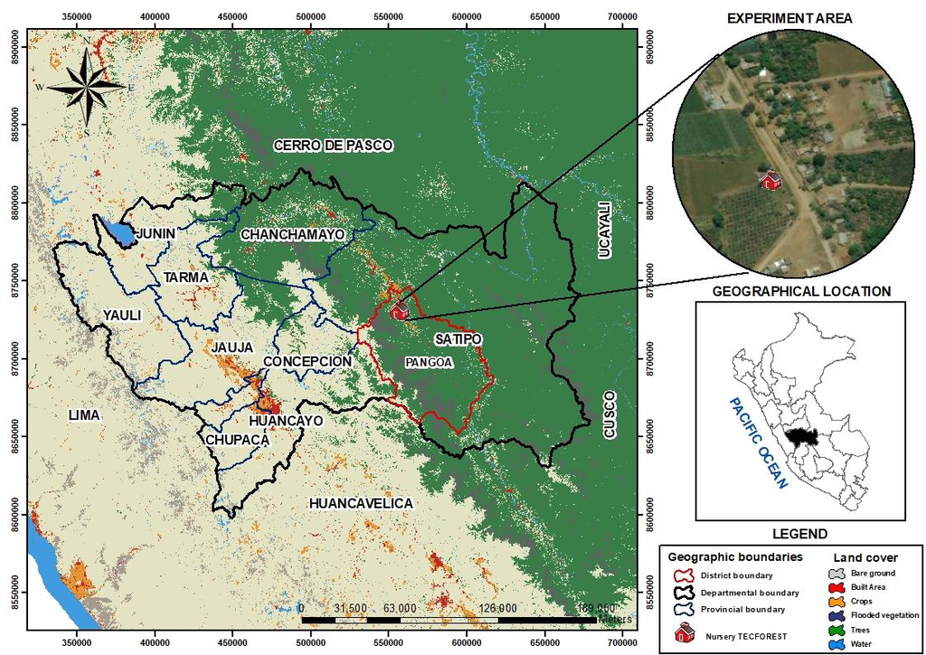

Figure 1: Geographical location of the experimental research area of the clonal propagation study of *Eucalyptus grandis × E. urophylla* with indole-3-butyric acid. Forest nursery of TEC FOREST S.A.C., San Martín de Pangoa district, Junín department, Peruvian central jungle.

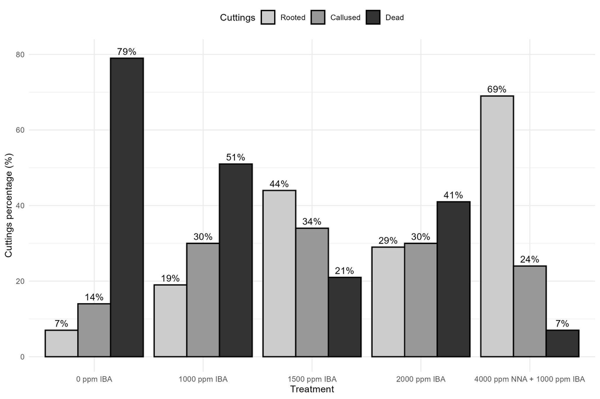

Figure 2: Status of *E. grandis × E. urophylla* cutting in response to the application of different concentrations of indole-3-butyric acid (IBA) at the end of the rooting period.

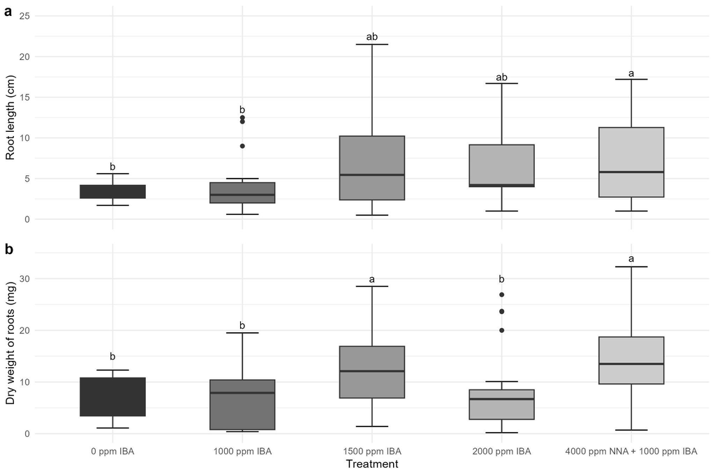

Figure 3: Root development of *Eucalyptus grandis × E. urophylla* cuttings for each applied dose of indole-3-butyric acid (IBA) at the end of the rhizogenesis process. (a) Root length (cm) (b) Root dry weight (mg). Results of Fisher’s least significant difference (LSD) test. Groups are assigned according to mean difference probability (α = 0.05). Treatments with the same letter are not significantly different (p-value < 0.05, n = 151).

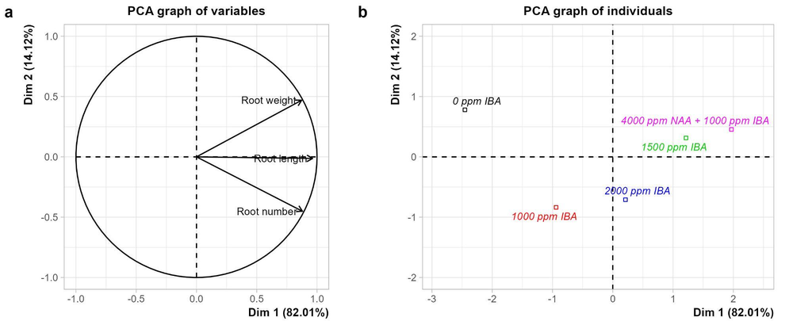

Figure 4: Principal Component Analysis (PCA) of root development variables based on the application of different doses of indole-3-butyric acid (IBA). (a) Evaluation of variables to determine the effect of the growth regulator on root system characteristics. (b) Treatment grouping based on IBA concentrations to identify the optimal dose for maximizing root development. The analysis was conducted on 151 observations (n = 151).

Table 1: Results of Fisher’s least significant difference (LSD) test for indole-3-butyric acid (IBA) dosage based on the number of roots variable. Groups are assigned according to mean difference probability (α = 0.05). Treatments with the same letter are not significantly different (p-value < 0.05, n = 151).

| **Treatments** | **Mean** | **Standard desviation** | **Minimum** | **Maximum** | **Significance** |
| --- | --- | --- | --- | --- | --- |
| T0 | 1.833 | 0.753 | 1 | 3 | a |
| T1 | 2.176 | 1.131 | 1 | 4 | a |
| T2 | 2.200 | 1.244 | 1 | 6 | a |
| T3 | 2.192 | 1.167 | 1 | 5 | a |
| T4 | 2.274 | 1.089 | 1 | 5 | a |